# ODRCC Simulation Study: Reproducibility and Diagnostic Report

Outcome-dependent right-censored covariate estimators

2026-11-07

# 1 Overview

This report documents the computational record behind the simulation study. It covers three things a reader may wish to verify independently: that the reported replicates are reproducible from their seeds; how many replicates completed and how the failures break down; and the full sampling distribution of each estimator, not only its bias and coverage. A final section summarizes the stability of the guarded augmentation matrix $\Lambda$.

Every replicate is written to a file named `est_results_n_<n>_<c_int>_seed_<seed>.csv`; the sample size, the censoring intercept `c_int`, and the integer seed are encoded in the file name, so each summary below traces back to a specific seeded draw. The data-generating function and all estimators are in `helper_data.R` and `helper_mestimate.R`; regenerating a replicate requires only its `(n, c_int, seed)` triple.

# 2 Assembling the estimates

```r
res_dir <- params$results_dir
files <- list.files(res_dir, pattern = "^est_results_n_[0-9].*\\.csv$",
                    full.names = TRUE)

cache_path <- file.path(res_dir, params$cache_rds)
if (!params$reread && file.exists(cache_path)) {
  dat <- readRDS(cache_path)
} else {
  rd <- function(f) {
    out <- tryCatch(fread(f, showProgress = FALSE), error = function(e) NULL)
    out
  }
  lst <- lapply(files, rd)
  dat <- rbindlist(lst, use.names = TRUE, fill = TRUE)
  saveRDS(dat, cache_path)
}

# tidy types and a readable method label
dat <- dat %>%
  mutate(across(c(beta0, beta1, beta2, sigma,
                  sebeta0, sebeta1, sebeta2, pcen), as.numeric),
         n = as.integer(n)) %>%
  mutate(method = recode(Method,
    "oracle"          = "Oracle",
    "naive"           = "Naive",
    "cc"              = "Complete case",
    "ipw"             = "IPW (known)",
    "ipw-est"         = "IPW",
    "mle-est"         = "MLE",
    "aipw"            = "AIPW unguarded (known)",
    "aipw-est"        = "AIPW unguarded",
    "aipw-lambda"     = "Guarded AIPW (known)",
    "aipw-lambda-est" = "Guarded AIPW"))

# censoring bins: left-closed, right-open, top reported bin closed
## Censoring bins: left-closed, right-open, [a, b); the last bin is [90, 100].
## Round first so that floating-point error does not move boundary replicates
## (e.g., in R, 0.7 < 7 * 0.1). No reported replicate falls at exactly 90%.
cens_bin10 <- function(p) {
  pct <- round(100 * p, 6)
  lab <- c("[0, 10)", "[10, 20)", "[20, 30)", "[30, 40)", "[40, 50)",
           "[50, 60)", "[60, 70)", "[70, 80)", "[80, 90)", "[90, 100]")
  idx <- pmin(floor(pct / 10) + 1, 10)
  factor(lab[idx], levels = lab)
}
dat <- dat %>%
  mutate(cens_bin = cens_bin10(pcen))

cat("Replicate-rows read:", nrow(dat),
    "| result files:", length(files),
    "| methods:", length(unique(dat$method)), "\n")
```

```
## Replicate-rows read: 178620 | result files: 17862 | methods: 10
```

# 3 Completeness and divergence audit

```r
n_breaks <- quantile(dat$n, probs = seq(0, 1, by = 0.25), na.rm = TRUE)
counts <- dat %>%
  filter(method == "Guarded AIPW") %>%
  mutate(n_bin = cut(n, breaks = unique(n_breaks),
                     right = FALSE, include.lowest = TRUE)) %>%
  group_by(n_bin, cens_bin) %>%
  summarise(replicates = n(), .groups = "drop") %>%
  pivot_wider(names_from = cens_bin, values_from = replicates, values_fill = 0)
counts
```

| n_bin | [10, 20) | [20, 30) | [30, 40) | [40, 50) | [50, 60) | [60, 70) | [70, 80) | [80, 90) | [90, 100] |
| --- | --- | --- | --- | --- | --- | --- | --- | --- | --- |
| [100,321) | 17 | 818 | 671 | 482 | 492 | 474 | 559 | 920 | 22 |
| [321,546) | 1 | 818 | 620 | 518 | 465 | 537 | 555 | 955 | 0 |
| [546,769) | 0 | 862 | 625 | 481 | 491 | 501 | 555 | 942 | 0 |
| [769,1e+03] | 0 | 880 | 591 | 541 | 485 | 516 | 561 | 907 | 0 |

```r
slurm_dir <- params$slurm_dir
outs <- list.files(slurm_dir, pattern = "\\.out$", full.names = TRUE)

scan_one <- function(f) {
  txt <- tryCatch(readLines(f, warn = FALSE), error = function(e) character(0))
  one <- paste(txt, collapse = "\n")
  data.frame(
    file       = basename(f),
    nonfinite  = grepl("non-finite function value", one, fixed = TRUE),
    notlist    = grepl("Model function must return a list", one, fixed = TRUE),
    divergent  = grepl("the integral is probably divergent", one, fixed = TRUE),
    singular   = grepl("computationally singular", one, fixed = TRUE),
    failed_tag = grepl("FAILED|Error", one)
  )
}
scan <- bind_rows(lapply(outs, scan_one))

divergence_table <- tibble::tibble(
  message = c("non-finite function value",
              "model function must return a list",
              "integral probably divergent",
              "computationally singular (Lambda inversion)"),
  log_files = c(sum(scan$nonfinite), sum(scan$notlist),
                sum(scan$divergent), sum(scan$singular))
)
divergence_table
```

| message | log_files |
| --- | --- |
| non-finite function value | 70 |
| model function must return a list | 57 |
| integral probably divergent | 30 |
| computationally singular (Lambda inversion) | 0 |

```r
cat("\nLog files scanned:", nrow(scan),
    "| any-error logs:", sum(scan$failed_tag), "\n")
```

```
##
## Log files scanned: 5000 | any-error logs: 3399
```

The guarded augmentation matrix is inverted in every replicate that reaches it; the row `computationally singular` is the count of logs in which that inversion failed. Divergence, when it occurs, is in the numerical integration and the weight computation, not in the matrix inversion; the next two sections show where the instability actually lives.

# 4 Sampling distributions

```r
reported <- c("Complete case", "IPW", "MLE",
              "AIPW unguarded", "Guarded AIPW")
mk <- function(d, cf, ecol, scol)
  transmute(d, method, n, cens_bin, coef = cf,
            est = .data[[ecol]], se = .data[[scol]])
base <- dat %>% filter(method %in% reported) %>%
  mutate(method = factor(method, levels = reported))
long <- bind_rows(
  mk(base, "beta0", "beta0", "sebeta0"),
  mk(base, "beta1", "beta1", "sebeta1"),
  mk(base, "beta2", "beta2", "sebeta2")) %>%
  mutate(tstat = (est - truth[coef]) / se) %>%
  filter(is.finite(tstat))
```

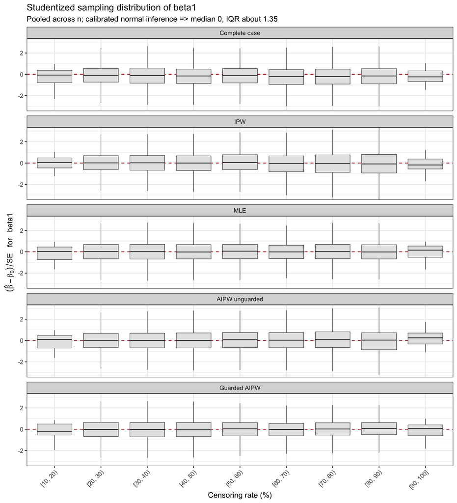

```r
plot_coef <- function(which_coef, qlim = c(0.01, 0.99), pad = 0.1) {
  d <- long %>% filter(coef == which_coef)
  yl <- quantile(d$tstat, qlim, na.rm = TRUE)
  yl <- yl + c(-1, 1) * pad * diff(yl)
  ggplot(d, aes(x = cens_bin, y = tstat)) +
    geom_hline(yintercept = 0, linetype = 2, colour = "firebrick") +
    geom_boxplot(outlier.shape = NA, fill = "grey90", linewidth = 0.3) +
    coord_cartesian(ylim = yl) +
    facet_wrap(~ method, ncol = 1) +
    labs(x = "Censoring rate (%)",
         y = bquote((hat(beta) - beta[0]) / SE ~ "  for  " ~ .(which_coef)),
         title = paste0("Studentized sampling distribution of ", which_coef),
         subtitle = "Pooled across n; calibrated normal inference => median 0, IQR about 1.35") +
    theme(axis.text.x = element_text(angle = 45, hjust = 1),
          panel.spacing = unit(0.5, "lines"))
}
plot_coef("beta1")
```

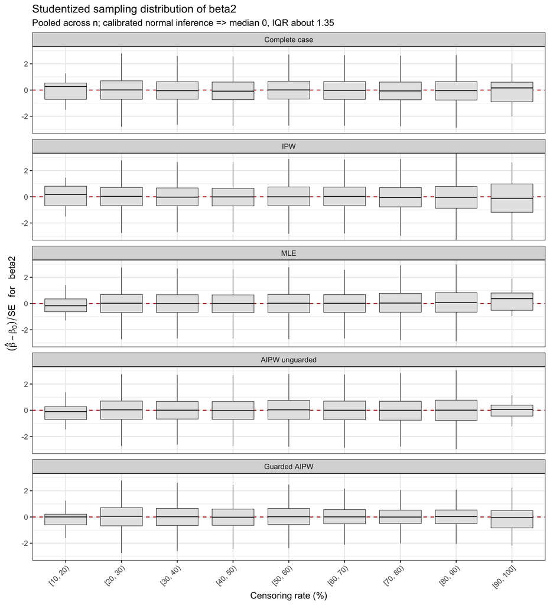

```r
plot_coef("beta2")
```

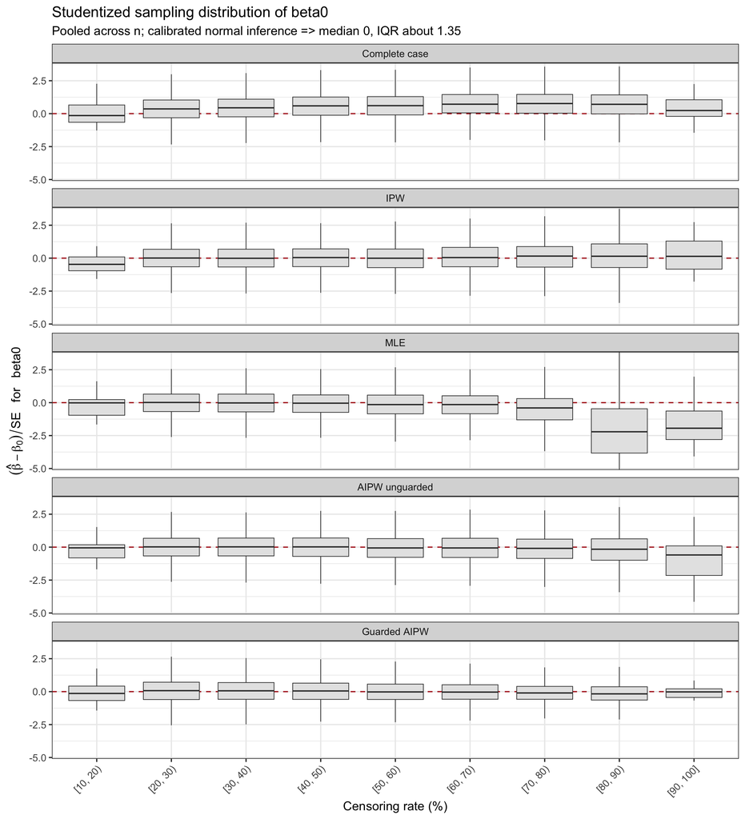

```r
plot_coef("beta0")
```

```r
# Calibration summary of the studentized statistic (target: median 0, IQR 1.35)
spread <- long %>%
  group_by(method, coef) %>%
  summarise(median_t = median(tstat, na.rm = TRUE),
            iqr_t    = IQR(tstat,    na.rm = TRUE),
            sd_t     = sd(tstat,     na.rm = TRUE),
            cover95  = mean(abs(tstat) <= qnorm(0.975), na.rm = TRUE),
            .groups  = "drop")
spread
```

| method | coef | median_t | iqr_t | sd_t | cover95 |
| --- | --- | --- | --- | --- | --- |
| Complete case | beta0 | 0.582318103 | 1.408134 | 1.0644867 | 0.8954204 |
| Complete case | beta1 | -0.149045713 | 1.373375 | 1.0404818 | 0.9380808 |
| Complete case | beta2 | -0.036818414 | 1.368364 | 1.0402009 | 0.9399843 |
| IPW | beta0 | 0.053127005 | 1.477204 | 1.1784273 | 0.9110962 |
| IPW | beta1 | -0.017791305 | 1.474214 | 1.1674626 | 0.9141753 |
| IPW | beta2 | -0.007847528 | 1.455621 | 1.1244688 | 0.9201657 |
| MLE | beta0 | -0.288464692 | 1.665520 | 11.2122745 | 0.8352586 |
| MLE | beta1 | 0.001948403 | 1.336425 | 5.5950768 | 0.9458260 |
| MLE | beta2 | 0.021896432 | 1.389945 | 1.4851716 | 0.9357537 |
| AIPW unguarded | beta0 | -0.047516602 | 1.434676 | 1.1919557 | 0.9265880 |

[output cut: 5 more lines]

Coverage of the nominal 95% interval for $\beta_1$, by censoring rate. Bins with fewer than 30 replicates are suppressed. The unguarded estimators lose coverage as censoring rises; the MLE and the guarded AIPW stay near nominal.

```r
cover_tab <- long %>%
  filter(coef == "beta1") %>%
  group_by(method, cens_bin) %>%
  summarise(reps = n(),
            cover95 = mean(abs(tstat) <= qnorm(0.975), na.rm = TRUE),
            .groups = "drop") %>%
  mutate(cover95 = ifelse(reps >= 30, round(cover95, 3), NA)) %>%
  select(-reps) %>%
  pivot_wider(names_from = method, values_from = cover95)
cover_tab
```

| cens_bin | Complete case | IPW | MLE | AIPW unguarded | Guarded AIPW |
| --- | --- | --- | --- | --- | --- |
| [10, 20) | NA | NA | NA | NA | NA |
| [20, 30) | 0.949 | 0.950 | 0.956 | 0.955 | 0.956 |
| [30, 40) | 0.941 | 0.937 | 0.945 | 0.939 | 0.941 |
| [40, 50) | 0.934 | 0.940 | 0.940 | 0.936 | 0.947 |
| [50, 60) | 0.941 | 0.938 | 0.942 | 0.939 | 0.963 |
| [60, 70) | 0.938 | 0.922 | 0.954 | 0.936 | 0.966 |
| [70, 80) | 0.938 | 0.893 | 0.944 | 0.908 | 0.959 |
| [80, 90) | 0.927 | 0.849 | 0.937 | 0.883 | 0.939 |
| [90, 100] | NA | NA | NA | NA | NA |

# 5 Guarded-AIPW stability ($\Lambda$)

These diagnostics recompute, for each reported replicate, the matrix that the guarded AIPW estimator inverts, together with the weight behaviour that drives instability. `singular` flags a failed inversion; `kappa_part2` is the condition number of the inverted matrix; `ess_frac` is the effective sample size of the weights as a fraction of $n$; `min_myp` is the smallest estimated selection probability.

```r
lam <- fread(params$lambda_csv)
lam <- lam %>%
  mutate(cens_bin = cens_bin10(pcen))
lam_summary <- lam %>%
  group_by(cens_bin) %>%
  summarise(reps          = n(),
            singular      = sum(singular),
            med_kappa     = median(kappa_part2, na.rm = TRUE),
            p95_kappa     = quantile(kappa_part2, 0.95, na.rm = TRUE),
            med_ess_frac  = median(ess_frac, na.rm = TRUE),
            p05_ess_frac  = quantile(ess_frac, 0.05, na.rm = TRUE),
            med_min_myp   = median(min_myp, na.rm = TRUE),
            .groups = "drop")
lam_summary
```

| cens_bin | reps | singular | med_kappa | p95_kappa | med_ess_frac | p05_ess_frac | med_min_myp |
| --- | --- | --- | --- | --- | --- | --- | --- |
| [10, 20) | 18 | 0 | 7.173357 | 14.41747 | 0.9849550 | 0.9590872 | 0.54610115 |
| [20, 30) | 3378 | 0 | 5.946181 | 10.25378 | 0.9813603 | 0.9640927 | 0.45674460 |
| [30, 40) | 2507 | 0 | 6.306336 | 10.18474 | 0.9644662 | 0.9335122 | 0.35007513 |
| [40, 50) | 2022 | 0 | 7.018201 | 11.66831 | 0.9325895 | 0.8824493 | 0.24019631 |
| [50, 60) | 1933 | 0 | 8.203106 | 15.70604 | 0.8785489 | 0.7895474 | 0.15797894 |
| [60, 70) | 2028 | 0 | 10.040911 | 24.34258 | 0.7993758 | 0.6559425 | 0.09666655 |
| [70, 80) | 2230 | 0 | 14.150893 | 49.14510 | 0.6719736 | 0.4531937 | 0.05346886 |
| [80, 90) | 3724 | 0 | 22.598043 | 148.48260 | 0.5182947 | 0.2599326 | 0.02670871 |
| [90, 100] | 22 | 0 | 33.543189 | 146.68436 | 0.6143509 | 0.2806064 | 0.03779894 |

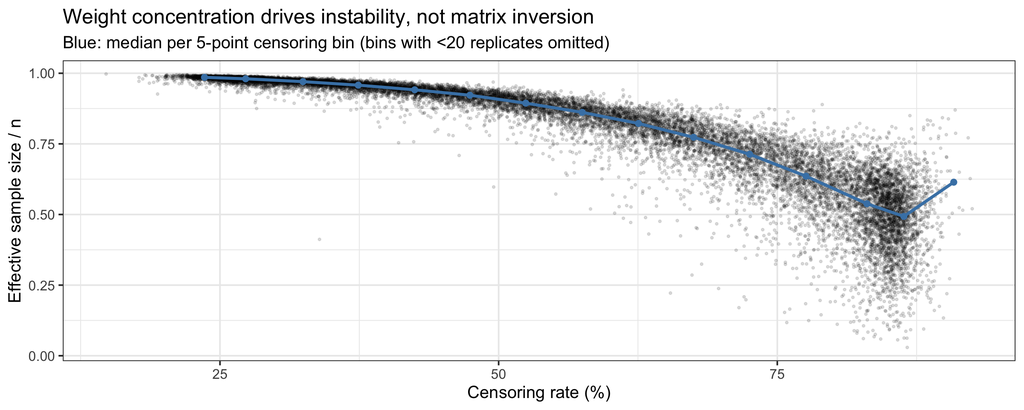

```r
lam_med <- lam %>%
  mutate(cb = cut(100 * pcen, breaks = seq(0, 100, by = 5),
                  right = FALSE, include.lowest = TRUE)) %>%
  group_by(cb) %>%
  summarise(x = mean(100 * pcen), med = median(ess_frac),
            reps = n(), .groups = "drop") %>%
  filter(reps >= 20)                      # drop sparse tail bins from the line
ggplot(lam, aes(x = 100 * pcen, y = ess_frac)) +
  geom_point(alpha = 0.12, size = 0.5) +
  geom_line(data = lam_med, aes(x = x, y = med),
            colour = "steelblue", linewidth = 1) +
  geom_point(data = lam_med, aes(x = x, y = med),
             colour = "steelblue", size = 1.6) +
  labs(x = "Censoring rate (%)", y = "Effective sample size / n",
       title = "Weight concentration drives instability, not matrix inversion",
       subtitle = "Blue: median per 5-point censoring bin (bins with <20 replicates omitted)")
```

Across 17862 recomputed replicates, the inverted matrix was singular in 0. The condition number stays moderate while the effective sample size of the weights falls with the censoring rate; the instability is in the weights, not in the inversion.

# 6 Summary